# Reproducible Research - Wk 2 Peer Assignment

PT

2/18/2017

## Overview

This assignment makes use of data from a personal activity monitoring device. This device collects data at 5 minute intervals through out the day. The data consists of two months of data from an anonymous individual collected during the months of October and November, 2012 and include the number of steps taken in 5 minute intervals each day

## Processing the Dataset

Read in the data set and load packages needed for tidying and intrepreting the data

```r
activity = read.csv("activity.csv")
library(dplyr)
library(tidyr)
```

```r
library(ggplot2)
library(lubridate)
```

## What is mean total number of steps taken per day (ignore the missing values in the dataset)?

1.Calculate the total number of steps taken per day 2.Make a histogram of the total number of steps taken each day

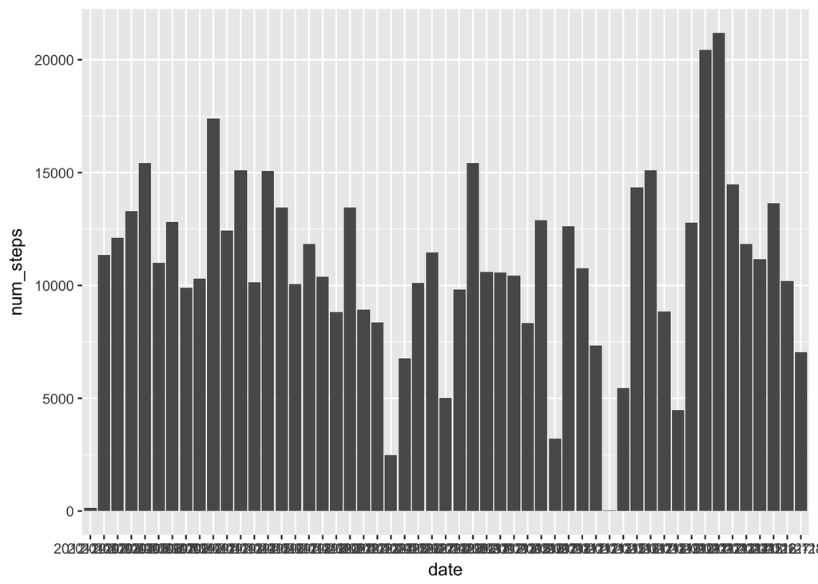

```r
x = activity %>%
      group_by(date) %>%
        summarise(num_steps = sum(steps)) %>%
          drop_na()
hist.plot = ggplot(x,aes(date,num_steps)) + geom_histogram(stat = "identity", binwidth = 15)
hist.plot
```

3.Calculate and report the mean and median of the total number of steps taken per day

```r
mean_steps_per.day = mean(x$num_steps)
median_steps_per.day = median(x$num_steps)
report = as.data.frame(matrix(c(mean_steps_per.day,median_steps_per.day),nrow = 1, ncol = 2))
colnames(report) <- c("mean","median")
report
```

```
##       mean median
## 1 10766.19  10765
```

## What is the average daily activity pattern?

1. Make a time series plot (i.e. 𝚝𝚢𝚙𝚎 = “𝚕”) of the 5-minute interval (x-axis) and the average number of steps taken, averaged across all days (y-axis)

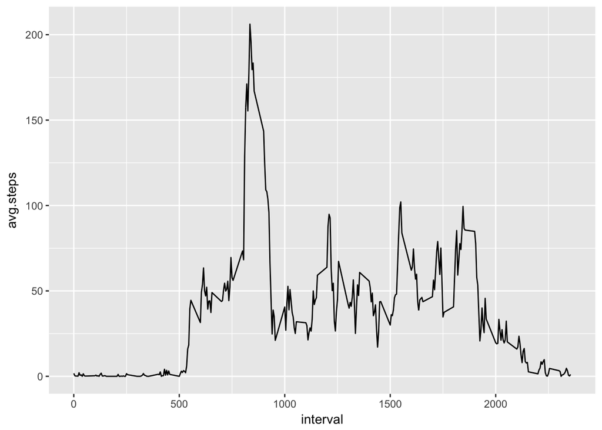

```r
averaged_interval = drop_na(activity) %>% group_by(interval) %>% summarise(avg.steps = mean(steps))
time.plot = ggplot(averaged_interval,aes(interval,avg.steps)) + geom_line()
time.plot
```

2. Which 5-minute interval, on average across all the days in the dataset, contains the maximum number of steps?

```r
averaged_interval[which(averaged_interval$avg.steps == max(averaged_interval$avg.steps)),]
```

```
## # A tibble: 1 × 2
##   interval avg.steps
##      <int>     <dbl>
## 1      835  206.1698
```

## Imputing missing values

1.Calculate and report the total number of missing values in the dataset (i.e. the total number of rows with 𝙽𝙰s)

```r
missing.values = apply(is.na(activity),2,sum)
missing.values
```

```
##    steps     date interval
##     2304        0        0
```

3.Create a new dataset that is equal to the original dataset but with the missing data filled in.I’ll use the mean for the 5-minute intervals to impute the missing data

```r
df.na = activity %>% filter(is.na(steps))
df.non_na = activity %>% filter(!is.na(steps))
imputed.na = merge(df.na, averaged_interval, by = "interval")
imputed.na = imputed.na[,c(4,3,1)]
colnames(imputed.na) <- c(names(df.na))
imputed.df = rbind(df.non_na,imputed.na)
```

4.Make a histogram of the total number of steps taken each day

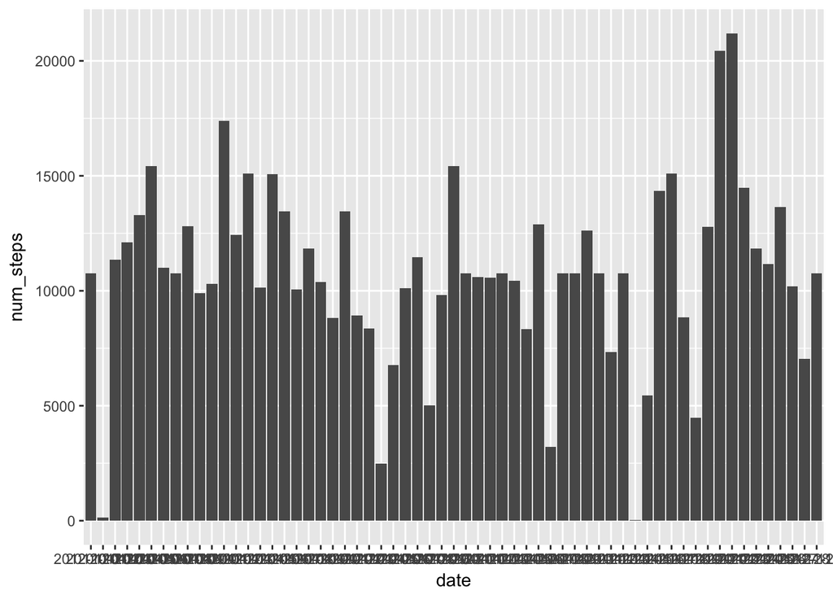

```r
y = imputed.df %>%
  group_by(date) %>%
  summarise(num_steps = sum(steps))

hist.plot.imputed = ggplot(y,aes(date,num_steps)) + geom_histogram(stat = "identity", binwidth = 15)
hist.plot.imputed
```

Calculate and report the mean and median total number of steps taken per day. Do these values differ from the estimates from the first part of the assignment? What is the impact of imputing missing data on the estimates of the total daily number of steps?

```r
imputed.mean_steps_per.day = mean(y$num_steps)
imputed.median_steps_per.day = median(y$num_steps)
mean.dif = imputed.mean_steps_per.day - mean_steps_per.day
med.dif = imputed.median_steps_per.day - median_steps_per.day
dif.report = as.data.frame(matrix(c(mean.dif,med.dif),nrow = 1, ncol = 2))
colnames(dif.report) <- c("mean dif","median dif")
dif.report
```

```
##   mean dif median dif
## 1        0   1.188679
```

## Are there differences in activity patterns between weekdays and weekends?

1.Create a new factor variable in the dataset with two levels – “weekday” and “weekend” indicating whether a given date is a weekday or weekend day.

```r
wk.imputed.df = imputed.df %>% mutate(period = wday(date,label = TRUE),weekday = wday(date,label = TRUE))
wkday <- c('Mon', 'Tues', 'Wed', 'Thurs', 'Fri')
wk.imputed.df$period = ifelse(wk.imputed.df$period %in% wkday, "Weekday", "Weekend")
avg.interval.wk.df = wk.imputed.df %>% group_by(interval,period) %>% summarise(avg.steps = mean(steps))
```

2.Make a panel plot containing a time series plot of the 5-minute interval (x-axis) and the average number of steps taken, averaged across all weekday days or weekend days (y-axis).

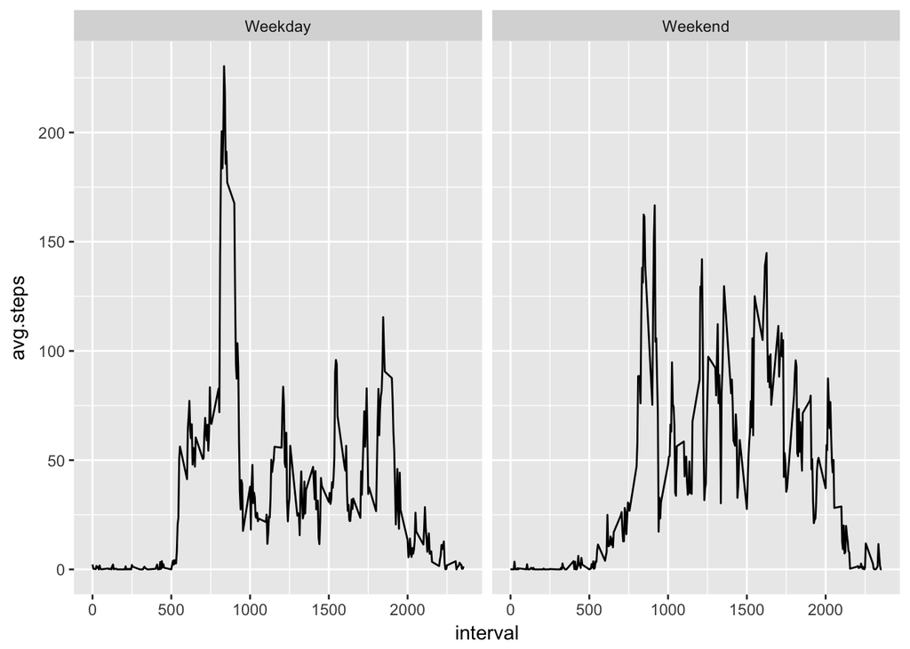

```r
wk.plot = ggplot(avg.interval.wk.df,aes(interval,avg.steps)) + geom_line() + facet_grid(.~period)
wk.plot
```